# Assignment 10B: NobelPrize.org

- Show All Code
- Hide All Code

DATA 607 · Code Base

Author

Dillon Leeper

Published

November 8, 2026

## Overview

| **Data** | Nobel Prize API v2.1, `/nobelPrizes` endpoint, pulled as JSON |
| --- | --- |
| **Focus** | The prize itself, not the winners: when it wasn’t given, what it was worth, how many people shared it, and what it was given for |
| **Join/compare question** | Q1 compares every year and category the prize *could* have been given against the ones it *was* |

## Key findings

- **Q1, The empty years:** almost two-thirds of the prizes never awarded fall during the two World Wars. Peace is withheld far more than any other category, and it’s the only one withheld after 1948.
- **Q2, The money:** the prize lost most of its real value by 1919, stayed low for decades, peaked in 2001, and is worth a little more today than in 1901.
- **Q3, Crowding:** three-way splits went from almost never to about 4 in 10 prizes, so the typical winner today takes home much less than an early winner did.
- **Q4, The wording:** the formal “in recognition of the services he has rendered” language faded, and each category’s vocabulary shifted with its field.

## Setup

```r
library(httr2)
library(jsonlite)
library(dplyr)
library(tidyr)
library(stringr)
library(ggplot2)
library(tidytext)
library(knitr)
library(scales)

theme_set(theme_minimal(base_size = 12))
```

## Getting the data

### Request

| Endpoint | `https://api.nobelprize.org/2.1/nobelPrizes` |
| --- | --- |
| Key needed | No |
| Paging | `offset` and `limit`. The first response’s `meta$count` gives the total, so the code loops until it has every prize |
| Sort | `asc`, oldest first |

```r
get_page <- function(offset, limit = 100) {
  request("https://api.nobelprize.org/2.1/nobelPrizes") |>
    req_url_query(offset = offset, limit = limit, sort = "asc") |>
    req_retry(max_tries = 3) |>
    req_perform() |>
    resp_body_json()
}

fetch_all_prizes <- function() {
  first_page <- get_page(0)
  total <- first_page$meta$count
  other_pages <- lapply(seq(100, total - 1, by = 100), get_page)
  pages <- c(list(first_page), other_pages)
  do.call(c, lapply(pages, `[[`, "nobelPrizes"))
}

snapshot_file <- "nobel_prizes_raw.json"

prizes_raw <- tryCatch(
  fetch_all_prizes(),
  error = function(e) {
    message("API unavailable, using saved snapshot: ", conditionMessage(e))
    read_json(snapshot_file)
  }
)

write_json(prizes_raw, snapshot_file, auto_unbox = TRUE, digits = NA)

length(prizes_raw)
```

```
[1] 688
```

The live API is tried first. Every successful pull also saves the raw JSON to `nobel_prizes_raw.json`, so the report still renders if the API is down.

### What one prize looks like

Each prize is a nested list. Category names come in three languages, and the laureates are a list inside the prize:

```r
str(prizes_raw[[1]], max.level = 2, list.len = 10)
```

```
List of 8
 $ awardYear          : chr "1901"
 $ category           :List of 3
  ..$ en: chr "Chemistry"
  ..$ no: chr "Kjemi"
  ..$ se: chr "Kemi"
 $ categoryFullName   :List of 3
  ..$ en: chr "The Nobel Prize in Chemistry"
  ..$ no: chr "Nobelprisen i kjemi"
  ..$ se: chr "Nobelpriset i kemi"
 $ dateAwarded        : chr "1901-11-12"
 $ prizeAmount        : int 150782
 $ prizeAmountAdjusted: int 10892857
 $ links              :List of 1
  ..$ :List of 4
 $ laureates          :List of 1
  ..$ :List of 7
```

### Tidying

Two tidy tables, built with `tidyr`’s rectangling functions:

| Table | One row per | Built with |
| --- | --- | --- |
| `prizes` | Prize (year + category) | `hoist()` pulls fields out of each prize, including nested ones like `category$en` |
| `prize_laureates` | Laureate per prize | `unnest_longer()` turns each prize’s laureate list into rows, then `hoist()` pulls their fields |

```r
sek_per_usd <- 9.89  # Swedish kronor per US dollar, early November 2026 (see Data Source)
usd <- function(x) vapply(x, function(v) dollar(v, accuracy = if (v < 1e6) 1 else 0.1,
                                                 scale_cut = cut_short_scale()), "")

prizes <- tibble(prize = prizes_raw) |>
  hoist(prize,
        year            = "awardYear",
        category        = c("category", "en"),
        amount          = "prizeAmount",
        amount_adjusted = "prizeAmountAdjusted",
        top_motivation  = c("topMotivation", "en"),
        laureates       = "laureates") |>
  select(-prize) |>
  mutate(year = as.integer(year),
         n_laureates = lengths(laureates),
         value_usd = amount_adjusted / sek_per_usd)

prize_laureates <- prizes |>
  select(year, category, value_usd, laureates) |>
  unnest_longer(laureates) |>
  hoist(laureates,
        laureate_id = "id",
        name        = c("knownName", "en"),
        org_name    = c("orgName", "en"),
        portion     = "portion",
        motivation  = c("motivation", "en")) |>
  select(-laureates) |>
  mutate(name = coalesce(name, org_name),
         share = 1 / as.numeric(str_extract(portion, "\\d+$")),
         take = value_usd * share)

prizes |>
  head(5) |>
  transmute(Year = year, Category = category,
            `Paid then (SEK)` = comma(amount),
            `Worth today (SEK)` = comma(amount_adjusted),
            `Worth today (USD)` = dollar(value_usd, accuracy = 1),
            Winners = n_laureates)
```

| Year | Category | Paid then (SEK) | Worth today (SEK) | Worth today (USD) | Winners |
| --- | --- | --- | --- | --- | --- |
| 1901 | Chemistry | 150,782 | 10,892,857 | $1,101,401 | 1 |
| 1901 | Literature | 150,782 | 10,892,857 | $1,101,401 | 1 |
| 1901 | Peace | 150,782 | 10,892,857 | $1,101,401 | 2 |
| 1901 | Physics | 150,782 | 10,892,857 | $1,101,401 | 1 |
| 1901 | Physiology or Medicine | 150,782 | 10,892,857 | $1,101,401 | 1 |

```r
prize_laureates |> select(year, category, name, portion, share, motivation) |> head(5)
```

| year | category | name | portion | share | motivation |
| --- | --- | --- | --- | --- | --- |
| 1901 | Chemistry | Jacobus H. van ’t Hoff | 1 | 1.0 | in recognition of the extraordinary services he has rendered by the discovery of the laws of chemical dynamics and osmotic pressure in solutions |
| 1901 | Literature | Sully Prudhomme | 1 | 1.0 | in special recognition of his poetic composition, which gives evidence of lofty idealism, artistic perfection and a rare combination of the qualities of both heart and intellect |
| 1901 | Peace | Henry Dunant | 1/2 | 0.5 | for his humanitarian efforts to help wounded soldiers and create international understanding |
| 1901 | Peace | Frédéric Passy | 1/2 | 0.5 | for his lifelong work for international peace conferences, diplomacy and arbitration |
| 1901 | Physics | Wilhelm Conrad Röntgen | 1 | 1.0 | in recognition of the extraordinary services he has rendered by the discovery of the remarkable rays subsequently named after him |

Checks before answering anything:

```r
share_check <- prize_laureates |>
  group_by(year, category) |>
  summarise(total_share = sum(share), .groups = "drop")

tibble(
  Check = c("Prizes pulled", "Laureate rows",
            "Prizes with no laureates", "Prizes whose shares add up to 1"),
  Result = c(nrow(prizes), nrow(prize_laureates),
             sum(prizes$n_laureates == 0),
             paste(sum(abs(share_check$total_share - 1) < 1e-9), "of", nrow(share_check)))
)
```

| Check | Result |
| --- | --- |
| Prizes pulled | 688 |
| Laureate rows | 1036 |
| Prizes with no laureates | 49 |
| Prizes whose shares add up to 1 | 639 of 639 |

**Money:** the API reports amounts in Swedish kronor (SEK), the currency the Nobel Foundation pays in. `prizeAmountAdjusted` is each prize in today’s kronor, adjusted for inflation, so years compare fairly. I convert it to **today’s US dollars** at 9.89 kronor per dollar (`value_usd`). `prizeAmount`, what was actually paid at the time, stays in kronor, since converting a 1901 payment at today’s exchange rate wouldn’t mean anything.

# Q1: The empty years

**Which years and categories had no prize awarded, and why do they cluster?**

**Approach:** build every year-and-category combination the prize could have been given (Economics only from 1969), then `anti_join()` it against the prizes that actually have laureates. Whatever is left was never awarded.

```r
categories <- tibble(
  category = c("Physics", "Chemistry", "Physiology or Medicine",
               "Literature", "Peace", "Economic Sciences"),
  first_year = c(rep(1901L, 5), 1969L)
)

all_possible <- categories |>
  cross_join(tibble(year = 1901:max(prizes$year))) |>
  filter(year >= first_year)

awarded <- prizes |> filter(n_laureates > 0)

not_awarded <- all_possible |>
  anti_join(awarded, by = c("year", "category")) |>
  mutate(period = case_when(
    between(year, 1914, 1918) ~ "World War I (1914-1918)",
    between(year, 1939, 1945) ~ "World War II (1939-1945)",
    TRUE ~ "Other years"
  ))

missing_from_api <- all_possible |> anti_join(prizes, by = c("year", "category"))
```

- **Possible prizes:** 688
- **Awarded:** 639
- **Never awarded:** **49**
- **Possible prizes missing from the API entirely:** 0. The API lists the empty years too, with a note like “No Nobel Prize was awarded this year,” so the join and the API agree.

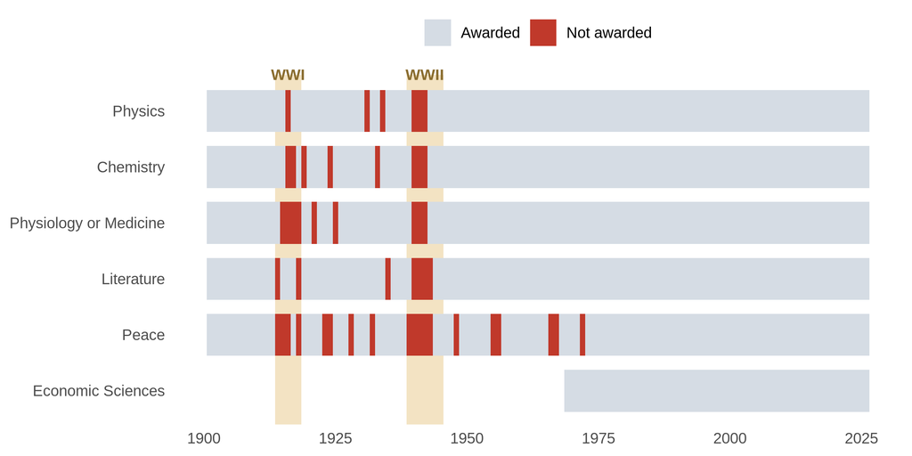

```r
category_order <- c("Economic Sciences", "Peace", "Literature",
                    "Physiology or Medicine", "Chemistry", "Physics")

all_possible |>
  left_join(not_awarded |> mutate(gap = TRUE) |> select(year, category, gap),
            by = c("year", "category")) |>
  mutate(status = if_else(is.na(gap), "Awarded", "Not awarded"),
         category = factor(category, levels = category_order)) |>
  ggplot(aes(year, category, fill = status)) +
  annotate("rect", xmin = 1913.5, xmax = 1918.5, ymin = -Inf, ymax = Inf, fill = "#f3e3c3") +
  annotate("rect", xmin = 1938.5, xmax = 1945.5, ymin = -Inf, ymax = Inf, fill = "#f3e3c3") +
  geom_tile(height = 0.75) +
  annotate("text", x = c(1916, 1942), y = 6.65, label = c("WWI", "WWII"),
           size = 3.5, fontface = "bold", color = "#8a6d2f") +
  scale_fill_manual(values = c(Awarded = "#d5dce4", `Not awarded` = "#c0392b")) +
  scale_x_continuous(breaks = seq(1900, 2025, by = 25)) +
  coord_cartesian(clip = "off") +
  labs(x = NULL, y = NULL, fill = NULL) +
  theme(legend.position = "top", panel.grid = element_blank())
```

```r
not_awarded |>
  count(period, name = "Prizes not awarded") |>
  mutate(Share = percent(`Prizes not awarded` / sum(`Prizes not awarded`), accuracy = 1)) |>
  rename(Period = period)
```

| Period | Prizes not awarded | Share |
| --- | --- | --- |
| Other years | 18 | 37% |
| World War I (1914-1918) | 13 | 27% |
| World War II (1939-1945) | 18 | 37% |

```r
not_awarded |>
  group_by(Category = category) |>
  summarise(`Not awarded` = n(),
            `During a World War` = sum(period != "Other years"),
            `Last time` = max(year)) |>
  arrange(desc(`Not awarded`))
```

| Category | Not awarded | During a World War | Last time |
| --- | --- | --- | --- |
| Peace | 19 | 9 | 1972 |
| Physiology or Medicine | 9 | 7 | 1942 |
| Chemistry | 8 | 5 | 1942 |
| Literature | 7 | 6 | 1943 |
| Physics | 6 | 4 | 1942 |

**Answer:**

- **63%** of the missing prizes fall during the two World Wars.
- Outside the wars, most gaps are in the 1920s and early 1930s.
- **Peace** is withheld the most, and after 1948 it’s the only category ever skipped: 1955, 1956, 1966, 1967, and 1972.
- **Economics** has never been skipped.

# Q2: The money over time

**How has the real value of the prize changed since 1901?**

**Approach:** plot each year’s prize in today’s US dollars (`value_usd`). All categories get the same amount in a given year, so there’s one value per year.

```r
money <- prizes |>
  group_by(year) |>
  summarise(nominal = median(amount),
            adjusted = median(value_usd))

milestones <- bind_rows(
  money |> filter(year == min(year)) |> mutate(label = "First prize", vjust = -0.5),
  money |> slice_min(adjusted, n = 1) |> mutate(label = "Lowest", vjust = 1.4),
  money |> slice_max(adjusted, n = 1) |> mutate(label = "Highest", vjust = -0.5),
  money |> filter(year == max(year)) |> mutate(label = "Latest", vjust = -0.5)
)
```

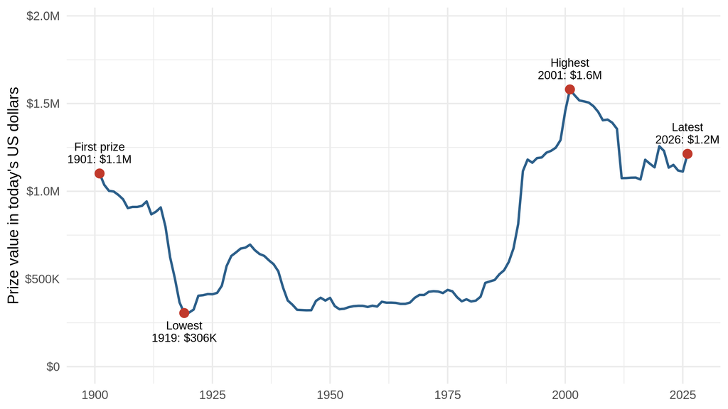

```r
ggplot(money, aes(year, adjusted)) +
  geom_line(color = "#2c5f8a", linewidth = 0.9) +
  geom_point(data = milestones, size = 3, color = "#c0392b") +
  geom_text(data = milestones,
            aes(label = paste0(label, "\n", year, ": ", usd(adjusted)),
                vjust = vjust),
            size = 3.2, lineheight = 0.9) +
  scale_y_continuous(limits = c(0, 1.95e6), labels = label_dollar(scale_cut = cut_short_scale())) +
  scale_x_continuous(breaks = seq(1900, 2025, by = 25), expand = expansion(add = 7)) +
  labs(x = NULL, y = "Prize value in today's US dollars")
```

**Paid vs. worth.** How much bigger is the prize than in 1901? There are two ways to answer:

- **Red, kronor on the check:** the amount paid, with no inflation adjustment
- **Blue, buying power:** what that amount can buy, adjusted for inflation (the chart above)

Both are shown as “times the 1901 prize,” so 1x means the same as 1901 and 2x means double:

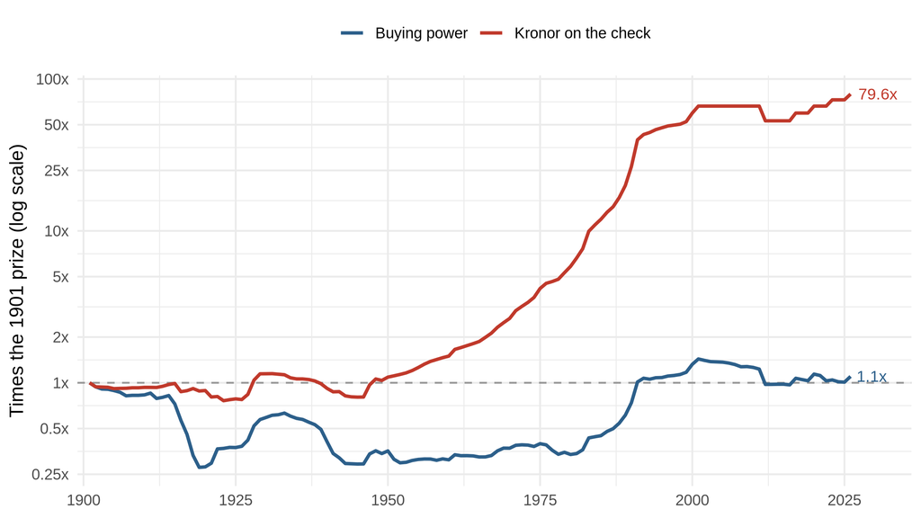

```r
growth <- money |>
  mutate(`Kronor on the check` = nominal / nominal[year == min(year)],
         `Buying power` = adjusted / adjusted[year == min(year)]) |>
  select(year, `Kronor on the check`, `Buying power`) |>
  pivot_longer(-year, names_to = "measure", values_to = "multiple")

growth_ends <- growth |> filter(year == max(year))

ggplot(growth, aes(year, multiple, color = measure)) +
  geom_hline(yintercept = 1, color = "grey60", linetype = "dashed") +
  geom_line(linewidth = 1) +
  geom_text(data = growth_ends, aes(label = paste0(round(multiple, 1), "x")),
            hjust = -0.2, size = 3.5, show.legend = FALSE) +
  scale_color_manual(values = c(`Kronor on the check` = "#c0392b",
                                `Buying power` = "#2c5f8a")) +
  scale_y_log10(breaks = c(0.25, 0.5, 1, 2, 5, 10, 25, 50, 100),
                labels = function(x) paste0(x, "x")) +
  scale_x_continuous(breaks = seq(1900, 2025, by = 25), expand = expansion(add = c(2, 10))) +
  labs(x = NULL, y = "Times the 1901 prize (log scale)", color = NULL) +
  theme(legend.position = "top")
```

**Takeaway:** the check is about 80 times bigger than in 1901, but prices rose almost as much, so its buying power is only about 1.1 times the first prize. For most of the 20th century (the blue line below 1x), the prize bought far less than it did in 1901.

```r
milestones |>
  transmute(Milestone = label, Year = year,
            `Amount paid at the time (SEK)` = comma(nominal),
            `In today's US dollars` = dollar(adjusted, accuracy = 1),
            `vs. 1901` = percent(adjusted / money$adjusted[money$year == min(money$year)], accuracy = 1))
```

| Milestone | Year | Amount paid at the time (SEK) | In today’s US dollars | vs. 1901 |
| --- | --- | --- | --- | --- |
| First prize | 1901 | 150,782 | $1,101,401 | 100% |
| Lowest | 1919 | 133,127 | $305,624 | 28% |
| Highest | 2001 | 10,000,000 | $1,580,666 | 144% |
| Latest | 2026 | 12,000,000 | $1,213,347 | 110% |

**Answer:**

- **A fast collapse:** by 1919, the prize was worth 28% of its 1901 value.
- **A long low:** it didn’t get back to its 1901 value until 1991.
- **The peak:** 2001, at $1.6M in today’s dollars.
- **A cut:** in 2012 the amount paid dropped from 10,000,000 to 8,000,000 kronor.
- **On paper vs. in reality:** the amount paid grew 80x since 1901, but after inflation the prize is worth only 1.1x what it was.
- **Today:** $1.2M, 10% more than the first prize in real terms (1901’s prize is worth $1.1M today).

# Q3: Crowding

**Are prizes being shared by more winners over time, and how much does each winner get as a result?**

**Approach:** count laureates per awarded prize by decade. Then join each laureate’s `portion` (1, 1/2, 1/3 or 1/4) to the prize’s adjusted amount to get what each winner actually took home.

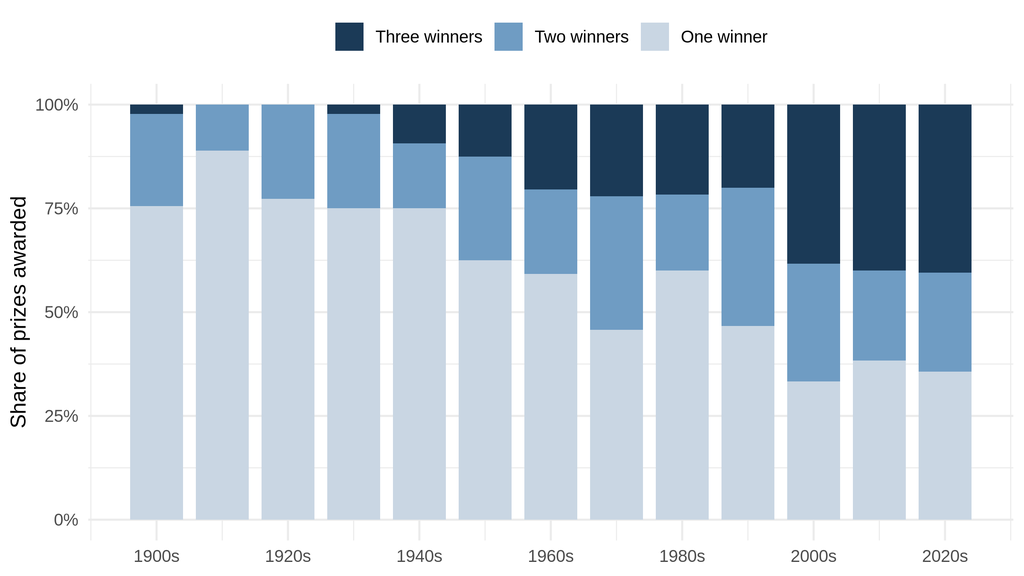

```r
split_by_decade <- awarded |>
  mutate(decade = year %/% 10 * 10,
         winners = factor(n_laureates, levels = 3:1,
                          labels = c("Three winners", "Two winners", "One winner"))) |>
  count(decade, winners) |>
  group_by(decade) |>
  mutate(share = n / sum(n)) |>
  ungroup()

ggplot(split_by_decade, aes(decade, share, fill = winners)) +
  geom_col(width = 8) +
  scale_fill_manual(values = c(`One winner` = "#c9d6e3", `Two winners` = "#6f9cc3",
                               `Three winners` = "#1b3a57")) +
  scale_y_continuous(labels = label_percent()) +
  scale_x_continuous(breaks = seq(1900, 2020, by = 20), labels = function(x) paste0(x, "s")) +
  labs(x = NULL, y = "Share of prizes awarded", fill = NULL) +
  theme(legend.position = "top")
```

By category, average winners per prize then and now:

```r
awarded |>
  mutate(era = case_when(year < 1950 ~ "1901-1949",
                         year >= 2000 ~ "2000-today",
                         TRUE ~ "1950-1999")) |>
  group_by(Category = category, era) |>
  summarise(avg = round(mean(n_laureates), 2), .groups = "drop") |>
  pivot_wider(names_from = era, values_from = avg) |>
  select(Category, `1901-1949`, `1950-1999`, `2000-today`) |>
  arrange(desc(`2000-today`)) |>
  mutate(across(-Category, ~ if_else(is.na(.x), "Not yet created", format(.x, nsmall = 2))))
```

| Category | 1901-1949 | 1950-1999 | 2000-today |
| --- | --- | --- | --- |
| Physics | 1.23 | 2.12 | 2.67 |
| Chemistry | 1.20 | 1.66 | 2.59 |
| Physiology or Medicine | 1.40 | 2.26 | 2.44 |
| Economic Sciences | Not yet created | 1.42 | 2.11 |
| Peace | 1.37 | 1.29 | 1.41 |
| Literature | 1.05 | 1.04 | 1.00 |

What each winner takes home, compared with the full prize:

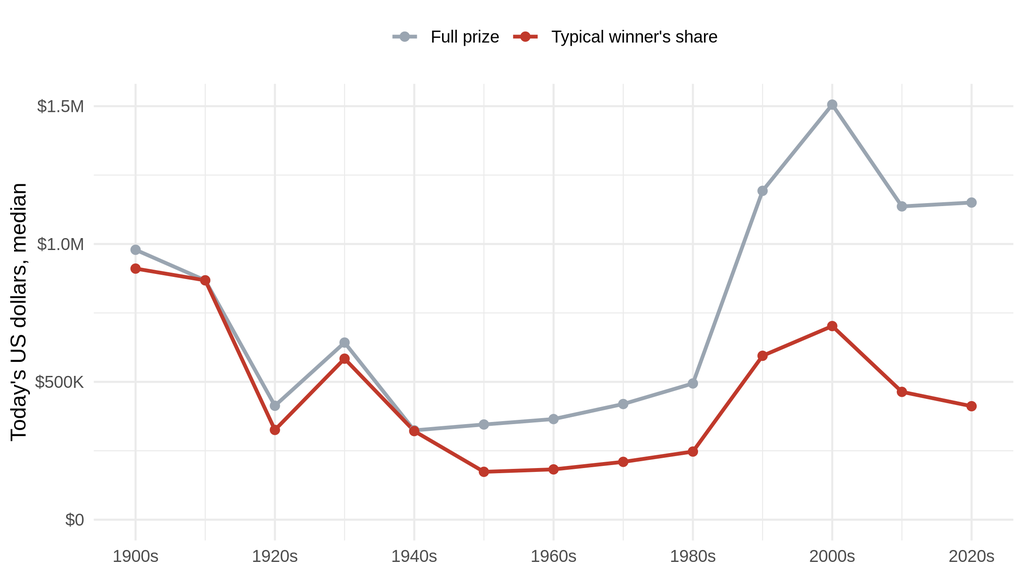

```r
take_by_decade <- prize_laureates |>
  mutate(decade = year %/% 10 * 10) |>
  group_by(decade) |>
  summarise(`Full prize` = median(value_usd),
            `Typical winner's share` = median(take)) |>
  pivot_longer(-decade, names_to = "measure", values_to = "value")

ggplot(take_by_decade, aes(decade, value, color = measure)) +
  geom_line(linewidth = 1) +
  geom_point(size = 2) +
  scale_color_manual(values = c(`Full prize` = "#9aa5b1", `Typical winner's share` = "#c0392b")) +
  scale_y_continuous(limits = c(0, NA), labels = label_dollar(scale_cut = cut_short_scale())) +
  scale_x_continuous(breaks = seq(1900, 2020, by = 20), labels = function(x) paste0(x, "s")) +
  labs(x = NULL, y = "Today's US dollars, median", color = NULL) +
  theme(legend.position = "top")
```

**Answer:**

- **Splitting is now normal:** 1% of prizes before 1940 went to three people, compared with 40% since 2000. Solo prizes fell from 79% to 36%.
- **It’s the sciences:** Physics, Chemistry and Medicine now average more than two winners per prize. Literature has never been split three ways.
- **Smaller checks:** the typical winner in the 2020s takes home $412K, compared with $911K in the 1900s, even though the full prize is worth about the same.

# Q4: What the prize rewards

**How has the wording of the prize motivations changed over the century?**

**Approach:** each laureate has a motivation (“for the discovery of…”). Winners who share the same motivation are counted once, then the text is split into words with `unnest_tokens()`, as in 10A.

```r
motivations <- prize_laureates |>
  distinct(year, category, motivation) |>
  mutate(decade = year %/% 10 * 10,
         era = case_when(year < 1950 ~ "1901-1949",
                         year >= 2000 ~ "2000-today",
                         TRUE ~ "1950-1999"))

motivation_words <- motivations |>
  unnest_tokens(word, motivation) |>
  anti_join(stop_words, by = "word")
```

How often key words appear, by decade:

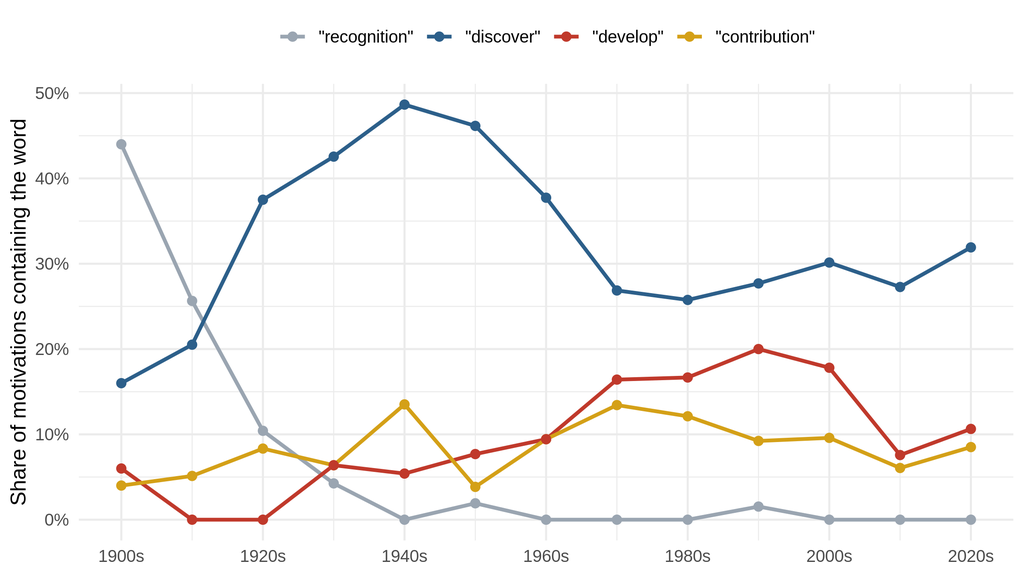

```r
keywords <- c(`"recognition"` = "recognition",
              `"discover"` = "discover",
              `"develop"` = "develop",
              `"contribution"` = "contribution")

keyword_trend <- motivations |>
  mutate(text = str_to_lower(motivation)) |>
  cross_join(tibble(keyword = names(keywords), pattern = unname(keywords))) |>
  mutate(has_word = str_detect(text, pattern)) |>
  group_by(decade, keyword) |>
  summarise(share = mean(has_word), .groups = "drop") |>
  mutate(keyword = factor(keyword, levels = names(keywords)))

ggplot(keyword_trend, aes(decade, share, color = keyword)) +
  geom_line(linewidth = 1) +
  geom_point(size = 2) +
  scale_color_manual(values = c("#9aa5b1", "#2c5f8a", "#c0392b", "#d4a017")) +
  scale_y_continuous(labels = label_percent()) +
  scale_x_continuous(breaks = seq(1900, 2020, by = 20), labels = function(x) paste0(x, "s")) +
  labs(x = NULL, y = "Share of motivations containing the word", color = NULL) +
  theme(legend.position = "top")
```

Top words in each category, then and now (numbers are how many motivations use the word):

```r
motivation_words |>
  filter(era != "1950-1999") |>
  count(category, era, word) |>
  group_by(category, era) |>
  slice_max(n, n = 5, with_ties = FALSE) |>
  summarise(words = paste0(word, " (", n, ")", collapse = ", "), .groups = "drop") |>
  pivot_wider(names_from = era, values_from = words, values_fill = "(category didn't exist)") |>
  rename(Category = category)
```

| Category | 1901-1949 | 2000-today |
| --- | --- | --- |
| Chemistry | recognition (14), chemistry (12), investigations (11), discovery (9), services (9) | development (12), discovery (7), studies (6), protein (5), synthesis (5) |
| Economic Sciences | (category didn’t exist) | analysis (13), economic (8), theory (8), contributions (5), analyzing (4) |
| Literature | recognition (9), life (7), poetic (7), art (6), poetry (6) | poetic (4), power (4), contemporary (3), experience (3), human (3) |
| Peace | peace (21), international (14), role (11), nations (9), war (9) | efforts (16), peace (10), rights (10), democracy (9), human (7) |
| Physics | discovery (25), recognition (8), radiation (7), services (7), physics (6) | discovery (16), contributions (6), optical (5), light (4), pioneering (4) |
| Physiology or Medicine | discovery (23), discoveries (8), recognition (8), played (4), relating (4) | discoveries (19), discovery (10), cells (5), system (4), cell (3) |

**Answer:**

- **The formal language faded:** “recognition” appears in 44% of motivations in the 1900s and 0% in the 2020s. Early prizes were “in recognition of the extraordinary services he has rendered.” Today’s just say “for” what was done.
- **Discovery is still the core of science prizes.** It peaked in the 1940s (49% of motivations) and is still among the top words in Physics and Medicine.
- **“Develop” grew,** especially in Chemistry, where “development” is now the top word: the prize increasingly rewards building methods and tools, not just finding things.
- **Each field shifted:**
  - **Peace** moved from “war,” “nations” and “international” to “rights,” “democracy” and “human.”
  - **Literature** kept “poetic” but traded “art” and “poetry” for “contemporary” and “experience.”

# Summary

| Question | Answer |
| --- | --- |
| **Q1** The empty years | 49 prizes never awarded, 63% during the World Wars. Peace is skipped the most and is the only one skipped after 1948 |
| **Q2** The money | Fell to 28% of its 1901 value by 1919, recovered in 1991, peaked in 2001, now $1.2M in today’s dollars |
| **Q3** Crowding | Three-way splits: 1% before 1940, 40% since 2000. The typical winner’s share is less than half what it was |
| **Q4** The wording | From formal “recognition” to plain “for…”. “Development” became Chemistry’s top word; Peace moved toward human rights and democracy |

# Data Source

Nobel Prize Outreach. (2026). *Nobel Prize API v2.1* [Data set]. Nobel Prize Developer Zone. https://www.nobelprize.org/about/developer-zone-2/. Accessed November 8, 2026. Terms of use: https://www.nobelprize.org/about/terms-of-use-for-api-nobelprize-org-and-data-nobelprize-org/

Exchange rate: USD/SEK 9.89, early November 2026. Pound Sterling Live (Barchart data). https://www.poundsterlinglive.com/data/currencies/usd-pairs/USDSEK-exchange-rate. Accessed November 8, 2026.

# AI Disclosure

Claude (Anthropic) helped write and test the code in this report: the paged API requests, the rectangling of the nested JSON, the four analyses and the charts. I chose the four questions in my approach.

Anthropic. (2026). *Claude* [Large language model]. https://claude.ai/. Accessed November 8, 2026.